# analyse du titanic

Kempf Mathilde

2026-11-12

## 1. Présentation des données

Le jeu de données TitanicSurvival, disponible dans le package carData, contient des informations sur les passagers du Titanic.

L’objectif de cette analyse est d’étudier les caractéristiques des passagers et leur survie en fonction de différentes variables.

```r
# Installer carData uniquement si nécessaire
if (!requireNamespace("carData", quietly = TRUE)) {
  install.packages("carData", repos = "https://cloud.r-project.org")
}

# Charger les données
data("TitanicSurvival", package = "carData")

# Afficher les premières lignes
head(TitanicSurvival)
```

```
##                                 survived    sex     age passengerClass
## Allen, Miss. Elisabeth Walton        yes female 29.0000            1st
## Allison, Master. Hudson Trevor       yes   male  0.9167            1st
## Allison, Miss. Helen Loraine          no female  2.0000            1st
## Allison, Mr. Hudson Joshua Crei       no   male 30.0000            1st
## Allison, Mrs. Hudson J C (Bessi       no female 25.0000            1st
## Anderson, Mr. Harry                  yes   male 48.0000            1st
```

```r
# Examiner la structure des données
str(TitanicSurvival)
```

```
## 'data.frame':    1309 obs. of  4 variables:
##  $ survived      : Factor w/ 2 levels "no","yes": 2 2 1 1 1 2 2 1 2 1 ...
##  $ sex           : Factor w/ 2 levels "female","male": 1 2 1 2 1 2 1 2 1 2 ...
##  $ age           : num  29 0.917 2 30 25 ...
##  $ passengerClass: Factor w/ 3 levels "1st","2nd","3rd": 1 1 1 1 1 1 1 1 1 1 ...
```

```r
# Dimensions du jeu de données
dim(TitanicSurvival)
```

```
## [1] 1309    4
```

## 2. Statistiques descriptives

Cette partie présente les principales caractéristiques des passagers du Titanic : leur survie, leur sexe, leur classe et leur âge.

```r
# Résumé général des variables
summary(TitanicSurvival)
```

```
##  survived      sex           age          passengerClass
##  no :809   female:466   Min.   : 0.1667   1st:323
##  yes:500   male  :843   1st Qu.:21.0000   2nd:277
##                         Median :28.0000   3rd:709
##                         Mean   :29.8811
##                         3rd Qu.:39.0000
##                         Max.   :80.0000
##                         NAs    :263
```

```r
# Répartition des passagers selon leur survie
table(TitanicSurvival$survived)
```

```
##
##  no yes
## 809 500
```

```r
# Répartition des passagers selon leur sexe
table(TitanicSurvival$sex)
```

```
##
## female   male
##    466    843
```

```r
# Répartition des passagers selon leur classe
table(TitanicSurvival$passengerClass)
```

```
##
## 1st 2nd 3rd
## 323 277 709
```

```r
# Statistiques descriptives de l'âge
mean(TitanicSurvival$age, na.rm = TRUE)
```

```
## [1] 29.88113
```

```r
median(TitanicSurvival$age, na.rm = TRUE)
```

```
## [1] 28
```

```r
sd(TitanicSurvival$age, na.rm = TRUE)
```

```
## [1] 14.4135
```

```r
# Nombre de valeurs manquantes par variable
colSums(is.na(TitanicSurvival))
```

```
##       survived            sex            age passengerClass
##              0              0            263              0
```

L’échantillon comprend 1 309 passagers du Titanic. Parmi eux, 500 ont survécu (38,2 %) et 809 sont décédés (61,8 %).

Les hommes sont majoritaires (843 contre 466 femmes). La troisième classe est la plus représentée, avec 709 passagers.

L’âge moyen est de 29,88 ans, avec une médiane de 28 ans et un écart-type de 14,41 ans. Cependant, 263 valeurs d’âge sont manquantes, soit environ 20,1 % des observations. Cette proportion devra être prise en compte lors de l’interprétation des analyses portant sur l’âge.

# 3. Visualisation des données

## 3.1. Survie selon le sexe

```r
# Tableau des proportions de survie selon le sexe
tab_sexe <- prop.table(
  table(TitanicSurvival$sex, TitanicSurvival$survived),
  margin = 1
)

# Affichage des pourcentages
round(tab_sexe * 100, 1)
```

```
##
##            no  yes
##   female 27.3 72.7
##   male   80.9 19.1
```

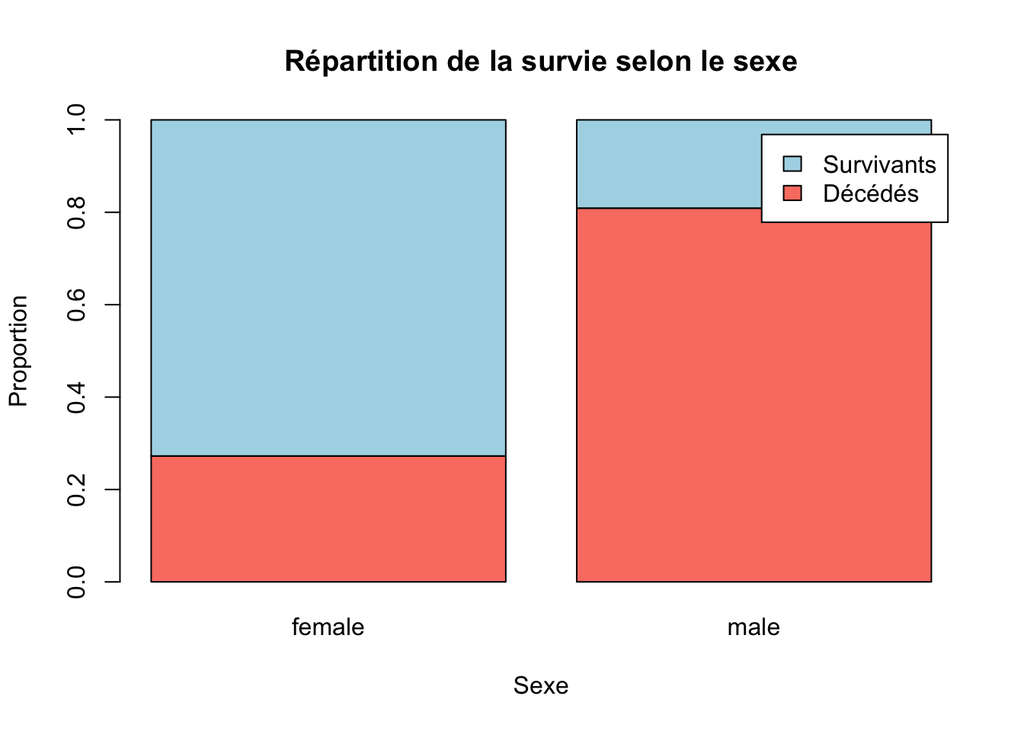

```r
# Graphique en barres
barplot(
  t(tab_sexe),
  col = c("salmon", "lightblue"),
  legend.text = c("Décédés", "Survivants"),
  main = "Répartition de la survie selon le sexe",
  xlab = "Sexe",
  ylab = "Proportion",
  ylim = c(0, 1)
)
```

## 3.2. Survie selon la classe

```r
# Calcul des proportions de survie par classe
tab_classe <- prop.table(
  table(TitanicSurvival$passengerClass, TitanicSurvival$survived),
  margin = 1
)

# Affichage des pourcentages
round(tab_classe * 100, 1)
```

```
##
##         no  yes
##   1st 38.1 61.9
##   2nd 57.0 43.0
##   3rd 74.5 25.5
```

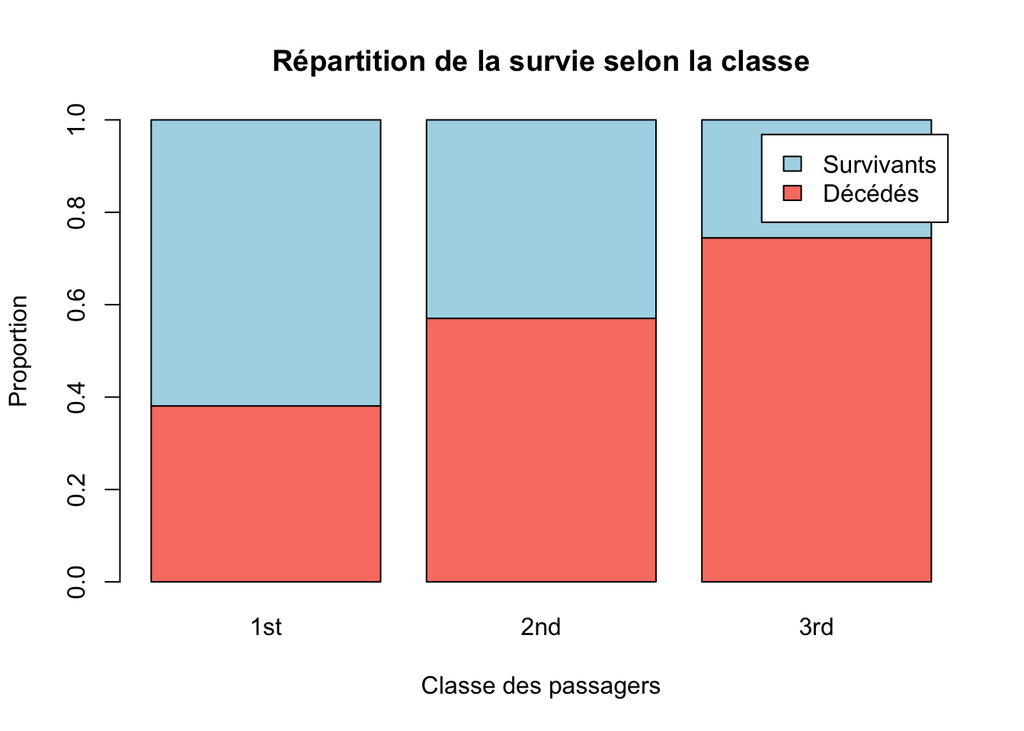

```r
# Graphique en barres
barplot(
  t(tab_classe),
  col = c("salmon", "lightblue"),
  legend.text = c("Décédés", "Survivants"),
  main = "Répartition de la survie selon la classe",
  xlab = "Classe des passagers",
  ylab = "Proportion",
  ylim = c(0, 1)
)
```

## 3.3. Âge selon la survie

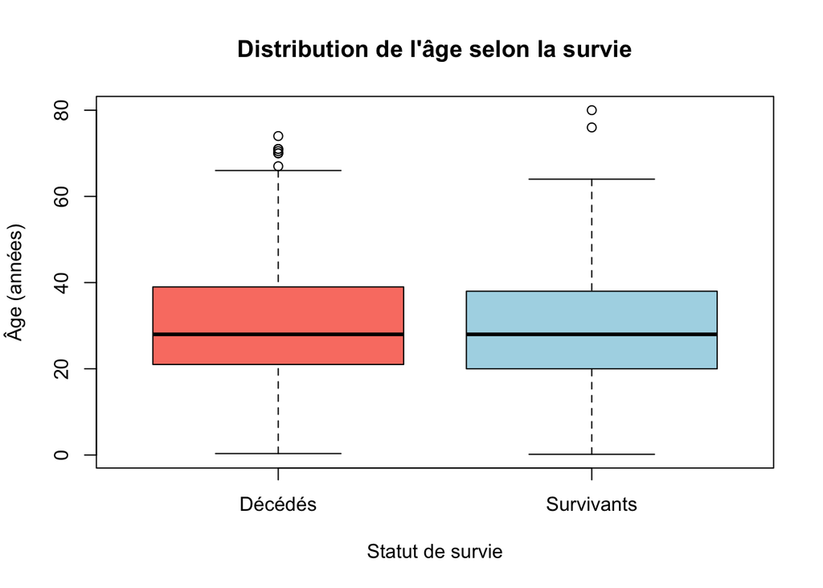

```r
# Boîtes à moustaches de l'âge selon la survie
boxplot(
  age ~ survived,
  data = TitanicSurvival,
  col = c("salmon", "lightblue"),
  main = "Distribution de l'âge selon la survie",
  xlab = "Statut de survie",
  ylab = "Âge (années)",
  names = c("Décédés", "Survivants")
)
```

```r
# Statistiques d'âge selon la survie
aggregate(
  age ~ survived,
  data = TitanicSurvival,
  FUN = median
)
```

```
##   survived age
## 1       no  28
## 2      yes  28
```

# 4. Interprétation des résultats

## 4.1. Influence du sexe sur la survie

Le graphique permet de comparer les proportions de survivants chez les femmes et chez les hommes. Il met en évidence une différence de survie selon le sexe, avec une proportion de survivantes plus importante chez les femmes.

## 4.2. Influence de la classe sur la survie

Le graphique montre que la survie varie selon la classe des passagers. Les passagers de première classe présentent une proportion de survivants plus élevée que ceux de deuxième et de troisième classe.

## 4.3. Influence de l’âge sur la survie

Les boîtes à moustaches permettent de comparer la distribution des âges entre les survivants et les passagers décédés.

La comparaison des médianes et de la dispersion permet d’étudier les différences entre les deux groupes. Cependant, 263 valeurs d’âge sont manquantes, ce qui limite l’interprétation de ce graphique.

## 4.4. Conclusion

Cette analyse descriptive suggère que la survie des passagers du Titanic est associée à plusieurs caractéristiques, notamment le sexe et la classe.

Ces résultats restent descriptifs : ils ne permettent pas, à eux seuls, de démontrer une relation causale entre ces variables et la survie.

# 5. Utilisation du package TitanicPackage

```r
library(TitanicPackage)

# Taux de survie selon le sexe
taux_survie(TitanicSurvival, "sex")
```

```
##   groupe effectif survivants taux_survie
## 1 female      466        339        72.7
## 2   male      843        161        19.1
```

```r
# Taux de survie selon la classe
taux_survie(TitanicSurvival, "passengerClass")
```

```
##   groupe effectif survivants taux_survie
## 1    1st      323        200        61.9
## 2    2nd      277        119        43.0
## 3    3rd      709        181        25.5
```

Les résultats obtenus à l’aide de notre package `TitanicPackage` confirment les tendances observées dans l’analyse descriptive. Le taux de survie est nettement supérieur chez les femmes (72,7 %) par rapport aux hommes (19,1 %).

La classe des passagers est également associée à la survie : 61,9 % des passagers de première classe ont survécu, contre 43,0 % en deuxième classe et 25,5 % en troisième classe.

Ces résultats montrent que le sexe et la classe sont associés à des différences importantes de survie parmi les passagers du Titanic.